# 02 Cultivation score weights

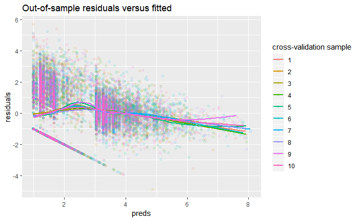

```r
plot_resids(clms, xval_inds, 'CAMPAIGN_NEWGIFT_CMIT_CREDIT')$outsample +
  scale_y_continuous(breaks = seq(-10, 10, by = 2))
```

At first glance, the linear trend evident in these results is concerning. Upon second glance, while still sobering it really just reinforces what we’d observed in the first of the two plots in the Background section: campaign giving is decidedly nonlinear as cultivation scores approach their high/low limits. As seen above, the underlying factors should be transformed, and possibly modeled nonlinearly (splines).

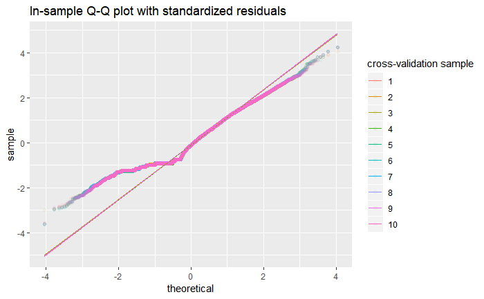

```r
plot_qq(clms, xval_inds, 'CAMPAIGN_NEWGIFT_CMIT_CREDIT')$insample +
  scale_y_continuous(breaks = seq(-10, 10, by = 2))
```

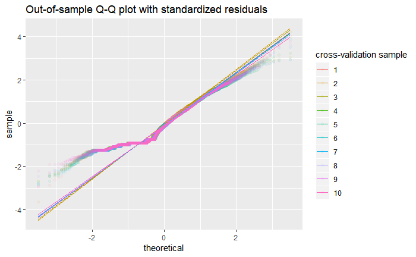

```r
plot_qq(clms, xval_inds, 'CAMPAIGN_NEWGIFT_CMIT_CREDIT')$outsample +
  scale_y_continuous(breaks = seq(-10, 10, by = 2))
```

The quantile-quantile plot further illustrates the issue. The drift above the reference line to the left and below it to the right suggests less density than expected in the tails, which follows given that the range is bound – it’s not possible to give less than a nondonor or (for practical purposes) more than a 9-figure donor.

The story is completely different when looking only at those who actually gave:

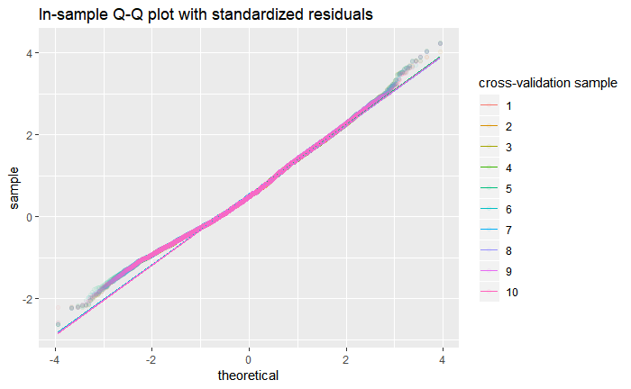

```r
plot_qq(clms, xval_inds, 'CAMPAIGN_NEWGIFT_CMIT_CREDIT', filter = 'truth > 0')$insample +
  scale_y_continuous(breaks = seq(-10, 10, by = 2))
```

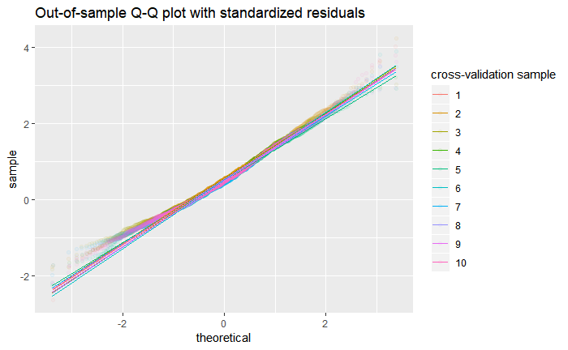

```r
plot_qq(clms, xval_inds, 'CAMPAIGN_NEWGIFT_CMIT_CREDIT', filter = 'truth > 0')$outsample +
  scale_y_continuous(breaks = seq(-10, 10, by = 2))
```

This is quite a bit nicer, suggesting only slight skewness in the tails.

**Takeaway.** When modeling giving amounts in the future, consider fitting a conditional model. Something along the lines of:

$$E(\text{giving amount} ~ | ~ \text{donor status} = 1)$$

## All predictors 1

The second model compares the variables underlying each PG score indicator, plus supplemental predictors. The first model incudes everything and I’ll prune from there using MSE. Initial spline df are fairly arbitrary.

```r
# List to store campaign linear models
clmaps <- list()
for(i in 1:length(xval_inds)) {
  # Create linear model excluding the holdout and out-of-sample indices
  clmaps[[i]] <- mdat %>%
    filter(rownum %in% unlist(xval_inds)[unlist(xval_inds) %nin% xval_inds[[i]]]) %>%
    lm(
      log10plus1(CAMPAIGN_NEWGIFT_CMIT_CREDIT) ~
        ACTIVE_PROPOSALS +
        ns(NUMERIC_AGE, df = 5) + # Underlying variable to AGE indicator
        PM_VISIT_LAST_2_YRS +
        log10plus1(VISIT_COUNT) + # Underlying VISITS_5PLUS indicator
        AF_25K_GIFT +
        sqrt(YEARS_OF_GIVING) + # Underlying GAVE_IN_LAST_3_YRS
        ns(YEARS_OF_GIVING_LAST_3, df = 2) + # Underlying GAVE_IN_LAST_3_YRS
        MG_250K_PLUS + # Decided to leave as factor
        PRESIDENT_VISIT +
        TRUSTEE_OR_ADVISORY_BOARD +
        Alumnus +
        DOUBLE_ALUM + # Deep Engagement component
        EVER_PARENT + # Deep Engagement component
        ns(SEASON_TICKET_YEARS, df = 1) + # Deep Engagement component
        CHICAGO_HOME +
        QUAL_LEVEL +
        AFFINITY_SCORE +
        MG_PR_MODEL_DESC
      , data = .
    )
}
```

Full results are in the appendix.

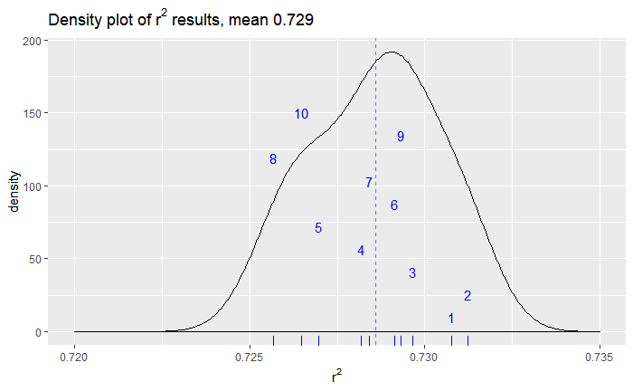

```r
plot_r2(clmaps) +
  geom_text(y = seq(10, 150, length.out = k - 1), label = 1:(k-1), color = 'blue') +
  xlim(c(.72, .735))
```

This is a much higher $r^2$ than seen above, but the model also includes many more predictors. Consider the MSE.

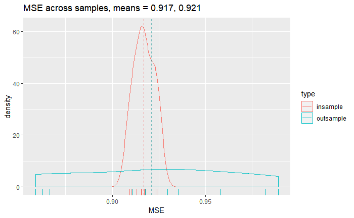

```r
plot_mses(clmaps, xval_inds, 'CAMPAIGN_NEWGIFT_CMIT_CREDIT')
```

Well, that’s pretty conclusive – this is also much lower than that seen previously. This implies that on average the predicted giving amount is less than a factor of 10 off. Which predictors contribute to the performance?

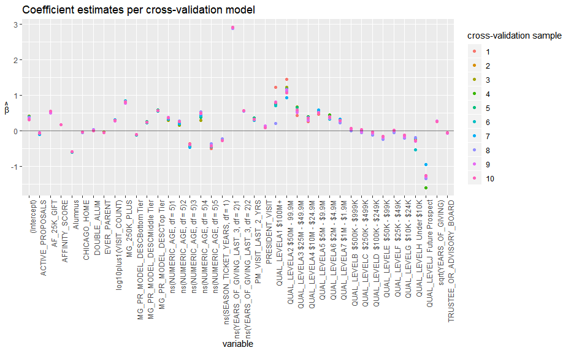

```r
plot_coefs(clmaps)
```

```r
coef_pm_table(clmaps, p.sig)
```

| variable | + | 0 | - |
| --- | --- | --- | --- |
| (Intercept) | 10 | 0 | 0 |
| ACTIVE_PROPOSALS | 0 | 8 | 2 |
| AF_25K_GIFT | 10 | 0 | 0 |
| AFFINITY_SCORE | 10 | 0 | 0 |
| Alumnus | 0 | 0 | 10 |
| CHICAGO_HOME | 0 | 8 | 2 |
| DOUBLE_ALUM | 0 | 10 | 0 |
| EVER_PARENT | 0 | 6 | 4 |
| log10plus1(VISIT_COUNT) | 10 | 0 | 0 |
| MG_250K_PLUS | 10 | 0 | 0 |

[output cut: 30 more lines]

After accounting for the other variables, things that don’t seem to matter include active proposals, Chicago home address, two of the deep engagement indicators, president visits, qualification level (inconsistent), and committee participation. Note that the “Future Prospect” factor level only appears 9 times – one of the cross-validation samples must not have had anyone rated at that level. Additionally, some of these are likely already included in the affinity score.

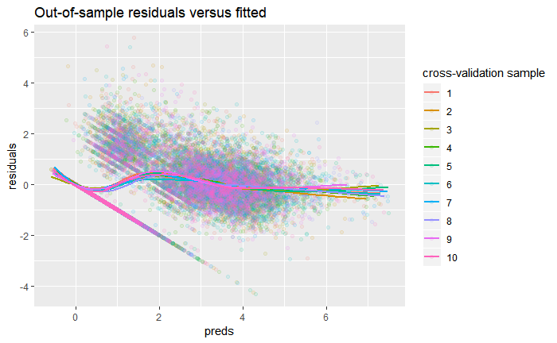

```r
plot_resids(clmaps, xval_inds, 'CAMPAIGN_NEWGIFT_CMIT_CREDIT')$outsample +
  scale_y_continuous(breaks = seq(-10, 10, by = 2))
```

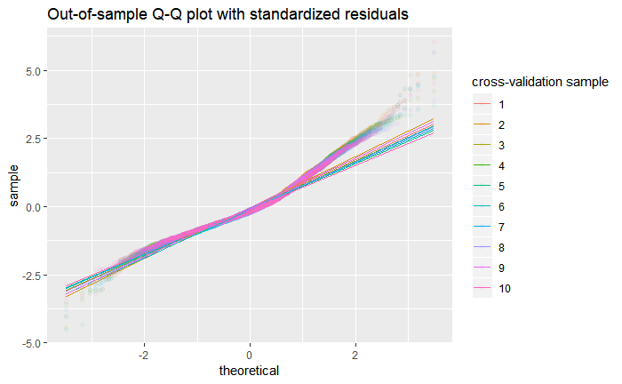

```r
plot_qq(clmaps, xval_inds, 'CAMPAIGN_NEWGIFT_CMIT_CREDIT')$outsample
```

This already looks a lot nicer than the Cultivation score predictors model! Now let’s try again, dropping the less-interesting predictors.

## All predictors 2

Full results are in the appendix.

```r
# List to store campaign linear models
clmaps2 <- list()
for(i in 1:length(xval_inds)) {
  # Create linear model excluding the holdout and out-of-sample indices
  clmaps2[[i]] <- mdat %>%
    filter(rownum %in% unlist(xval_inds)[unlist(xval_inds) %nin% xval_inds[[i]]]) %>%
    lm(
      log10plus1(CAMPAIGN_NEWGIFT_CMIT_CREDIT) ~
        ns(NUMERIC_AGE, df = 5) + # Underlying variable to AGE indicator
        PM_VISIT_LAST_2_YRS +
        log10plus1(VISIT_COUNT) + # Underlying VISITS_5PLUS indicator
        AF_25K_GIFT +
        sqrt(YEARS_OF_GIVING) + # Underlying GAVE_IN_LAST_3_YRS
        ns(YEARS_OF_GIVING_LAST_3, df = 2) + # Underlying GAVE_IN_LAST_3_YRS
        MG_250K_PLUS + # Decided to leave as factor
        Alumnus +
        ns(SEASON_TICKET_YEARS, df = 1) + # Deep Engagement component
        AFFINITY_SCORE +
        MG_PR_MODEL_DESC
      , data = .
    )
}
```

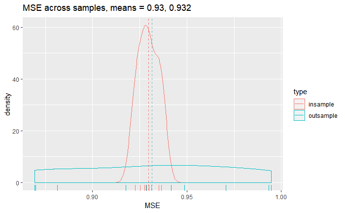

```r
plot_mses(clmaps2, xval_inds, 'CAMPAIGN_NEWGIFT_CMIT_CREDIT')
```

That’s a marginal increase in outsample MSE (0.9211 vs. 0.9316, difference of 1.14%) with many fewer predictors.

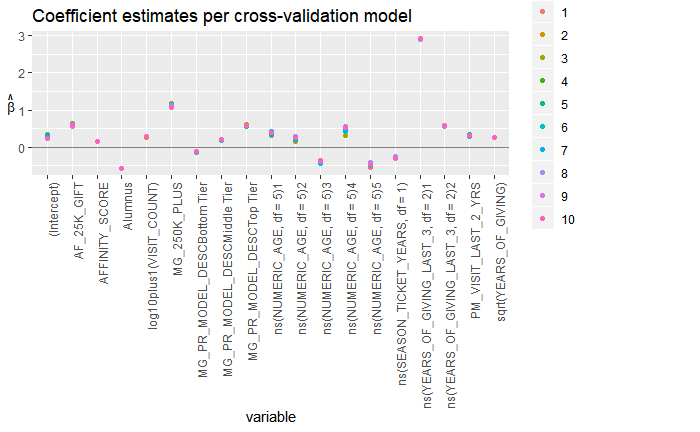

```r
plot_coefs(clmaps2)
```

```r
coef_pm_table(clmaps2, p.sig)
```

| variable | + | 0 | - |
| --- | --- | --- | --- |
| (Intercept) | 8 | 2 | 0 |
| AF_25K_GIFT | 10 | 0 | 0 |
| AFFINITY_SCORE | 10 | 0 | 0 |
| Alumnus | 0 | 0 | 10 |
| log10plus1(VISIT_COUNT) | 10 | 0 | 0 |
| MG_250K_PLUS | 10 | 0 | 0 |
| MG_PR_MODEL_DESCBottom Tier | 0 | 0 | 10 |
| MG_PR_MODEL_DESCMiddle Tier | 10 | 0 | 0 |
| MG_PR_MODEL_DESCTop Tier | 10 | 0 | 0 |
| ns(NUMERIC_AGE, df = 5)1 | 10 | 0 | 0 |

[output cut: 9 more lines]

The spline degrees of freedom for numeric age could be tweaked.

## All predictors splines test

```r
splines_max <- 10
clmaps3 <- list()
for (s in 1:splines_max) {
  clmaps3[[s]] <- list()
  for(i in 1:length(xval_inds)) {
    # Create linear model excluding the holdout and out-of-sample indices
    clmaps3[[s]][[i]] <- mdat %>%
      filter(rownum %in% unlist(xval_inds)[unlist(xval_inds) %nin% xval_inds[[i]]]) %>%
      lm(
        log10plus1(CAMPAIGN_NEWGIFT_CMIT_CREDIT) ~
          ns(NUMERIC_AGE, df = s) + # Underlying variable to AGE indicator
          PM_VISIT_LAST_2_YRS +
          log10plus1(VISIT_COUNT) + # Underlying VISITS_5PLUS indicator
          AF_25K_GIFT +
          sqrt(YEARS_OF_GIVING) + # Underlying GAVE_IN_LAST_3_YRS
          ns(YEARS_OF_GIVING_LAST_3, df = 2) + # Underlying GAVE_IN_LAST_3_YRS
          MG_250K_PLUS + # Decided to leave as factor
          Alumnus +
          ns(SEASON_TICKET_YEARS, df = 1) + # Deep Engagement component
          AFFINITY_SCORE +
          MG_PR_MODEL_DESC
        , data = .
      )
  }
}
```

Try different spline degrees of freedom for NUMERIC_AGE. Full results are in the appendix.

Consider the distribution of MSEs for each model.

```r
# Calculate MSEs for each model
spline_mse <- foreach(s = 1:splines_max, .combine = rbind) %do% {
  mses <- calc_outsample_mse(clmaps3[[s]], xval_inds, 'CAMPAIGN_NEWGIFT_CMIT_CREDIT')
  data.frame(spline.df = s, xv_group = factor(1:(k-1)), mses)
}
```

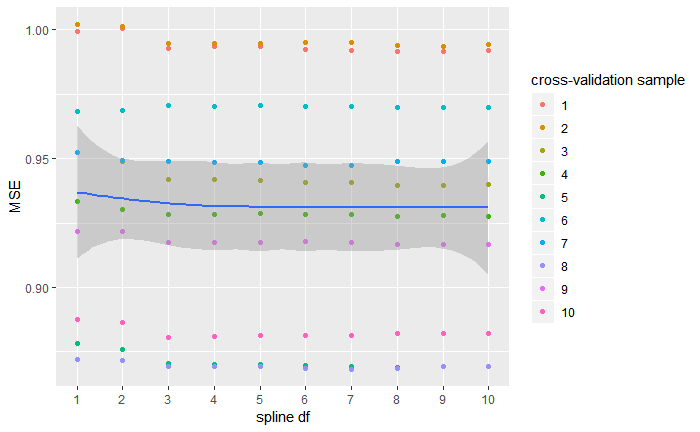

```r
# Plot results
spline_mse %>%
  ggplot(aes(x = spline.df, y = mses)) +
  geom_point(aes(color = xv_group)) +
  geom_smooth() +
  scale_x_continuous(breaks = 1:splines_max, minor_breaks = NULL) +
  labs(x = 'spline df', y = 'MSE', color = 'cross-validation sample')
```

For practical purposes there’s not much difference between the different choices. It looks like 4 or 5 is where the mean MSE levels out, so I’ll stick with my initial choice.

## Comparison

Create the two final models and check them on out-of-sample data.

```r
# Predict campaign giving, PG score indicators
clm_final <- lm(
  log10plus1(CAMPAIGN_NEWGIFT_CMIT_CREDIT) ~
    ACTIVE_PROPOSALS +
    AGE +
    PM_VISIT_LAST_2_YRS +
    VISITS_5PLUS +
    AF_25K_GIFT +
    GAVE_IN_LAST_3_YRS +
    MG_250K_PLUS +
    PRESIDENT_VISIT +
    TRUSTEE_OR_ADVISORY_BOARD +
    Alumnus +
    DEEP_ENGAGEMENT +
    CHICAGO_HOME
  , data = mdat %>% filter(rownum %in% unlist(xval_inds))
)
# Predict campaign giving, underlying factors
clmap_final <- lm(
  log10plus1(CAMPAIGN_NEWGIFT_CMIT_CREDIT) ~
    ns(NUMERIC_AGE, df = 5) + # Underlying variable to AGE indicator
    PM_VISIT_LAST_2_YRS +
    log10plus1(VISIT_COUNT) + # Underlying VISITS_5PLUS indicator
    AF_25K_GIFT +
    sqrt(YEARS_OF_GIVING) + # Underlying GAVE_IN_LAST_3_YRS
    ns(YEARS_OF_GIVING_LAST_3, df = 2) + # Underlying GAVE_IN_LAST_3_YRS
    MG_250K_PLUS + # Decided to leave as factor
    Alumnus +
    ns(SEASON_TICKET_YEARS, df = 1) + # Deep Engagement component
    AFFINITY_SCORE +
    MG_PR_MODEL_DESC
  , data = mdat %>% filter(rownum %in% unlist(xval_inds))
)
```

Full results in the appendix

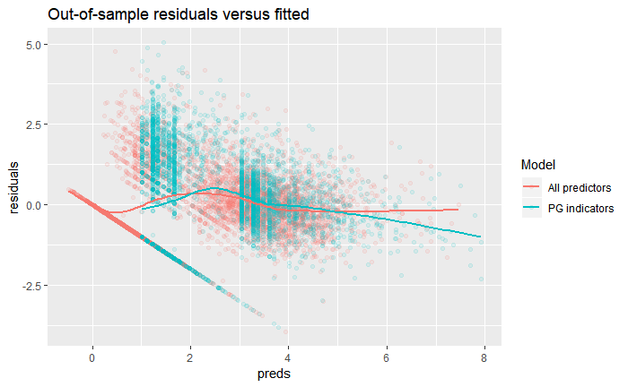

```r
plot_resids(list(clmap_final, clm_final), list(oos_inds, oos_inds), 'CAMPAIGN_NEWGIFT_CMIT_CREDIT')$outsample +
  scale_color_discrete(labels = c('All predictors', 'PG indicators')) +
  labs(color = 'Model')
```

The “All predictors” residuals look better than the “PG indicators”" residuals.

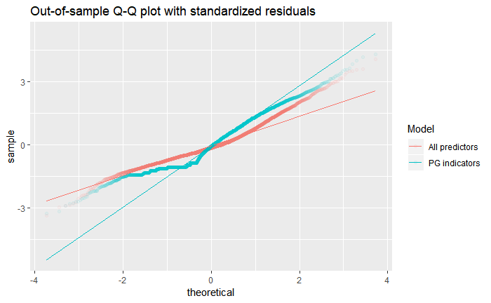

```r
plot_qq(list(clmap_final, clm_final), list(oos_inds, oos_inds), 'CAMPAIGN_NEWGIFT_CMIT_CREDIT')$outsample +
  scale_color_discrete(labels = c('All predictors', 'PG indicators')) +
  labs(color = 'Model')
```

Note the reference lines – “All predictors” is much closer to a normal distribution, albeit with some positive skewness.

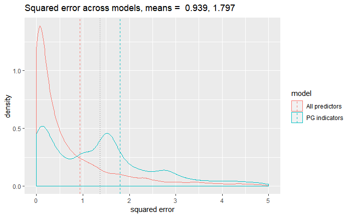

```r
c_mses_final <- rbind(
  calc_preds(list(clm_final), list(oos_inds), 'CAMPAIGN_NEWGIFT_CMIT_CREDIT')[[1]] %>%
    mutate(model = 'PG indicators')
  , calc_preds(list(clmap_final), list(oos_inds), 'CAMPAIGN_NEWGIFT_CMIT_CREDIT')[[1]] %>%
    mutate(model = 'All predictors')
) %>% mutate(
  model = factor(model)
  , sq.error = (truth - preds)^2
)
c_mses_final <- c_mses_final %>% left_join(
  c_mses_final %>% group_by(model) %>% summarise(mse = mean(sq.error))
  , by = c('model', 'model')
)
c_mses_final %>%
  ggplot(aes(x = sq.error, color = model)) +
  geom_density() +
  geom_vline(aes(xintercept = mean(sq.error)), linetype = 'dotted', alpha = .5) +
  geom_vline(aes(xintercept = mse, color = model), linetype = 'dashed') +
  xlim(c(0, 5)) +
  labs(
    x = 'squared error'
    , title = bquote('Squared error across models, means = ' ~
        .(c_mses_final %>% group_by(model) %>% summarise(mse = mean(mse)) %>% select(mse) %>%
            unlist() %>% round(3) %>% paste(collapse = ', ')))
  )
```

We never want to see bimodal squared errors – it looks like “All predictors” is a much better regression model. These are all very close to the results seen in the corresponding sections above, which is reassuring.

Finally, let’s look at the impact of age in the splines model. I’ll try plotting against both the raw $\textbf{y}$ and the partial residuals, which are obtained by removing the effects of all the predictors besides the $\textbf{x}_j$ we’re interested in, e.g.

$$\boldsymbol{\hat{\epsilon}} = \textbf{y} - \hat{\textbf{y}} = \textbf{y} - \sum_{i} {\textbf{x}_i \hat{\boldsymbol{\beta}}_i}$$
$$\boldsymbol{\hat{\epsilon}}_\text{partial} = \textbf{y} - \sum_{i \neq j} {\textbf{x}_i \hat{\boldsymbol{\beta}}_i}$$

```r
clmap_splines_dat <- data.frame(
  age = mdat %>% filter(rownum %in% unlist(xval_inds)) %>% select(NUMERIC_AGE) %>% unlist()
  , y = model.frame(clmap_final)[, 1]
  , y.hat = update(clmap_final, formula = . ~ ns(NUMERIC_AGE, df = 5)) %>% fitted()
  # Compute partial residuals
  , y.partial.resid = {clmap_final %>% residuals(type = 'partial')}[, 'ns(NUMERIC_AGE, df = 5)']
) %>% mutate(
  # Regression on partial residuals
  y.hat.partial = lm(y.partial.resid ~ ns(age, 5)) %>% fitted()
)
```

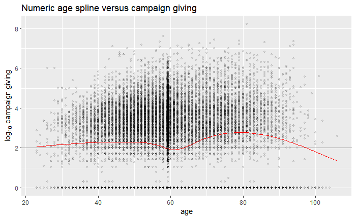

```r
clmap_splines_dat %>%
  ggplot(aes(x = age, y = y)) +
  geom_point(alpha = .1, size = 1) +
  geom_hline(yintercept = 2, color = 'darkgray') +
  geom_line(aes(y = y.hat), color = 'red') +
  labs(title = 'Numeric age spline versus campaign giving', y = bquote(log[10] ~ 'campaign giving'))
```

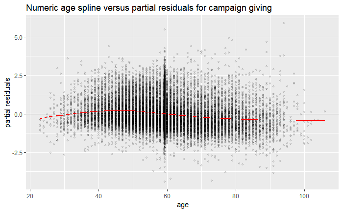

```r
clmap_splines_dat %>%
  ggplot(aes(x = age, y = y.partial.resid)) +
  geom_point(alpha = .1, size = 1) +
  geom_hline(yintercept = 0, color = 'darkgray') +
  geom_line(aes(y = y.hat.partial), color = 'red') +
  labs(title = 'Numeric age spline versus partial residuals for campaign giving'
       , y = 'partial residuals')
```

Recall that in the PG indicators model, age had a negative coefficient. This paints a more nuanced picture. The first plot regresses campaign giving on the natural spline of age and shows a dip in expected giving for 60-year-olds, a gradual increase to age 80 or so, and then a slow decline. However, we know from previous experience that age is closely correlated with many other predictors of giving (years of giving, total giving, capacity evaluation, and so on). The partial residual plot corrects for this by removing the effect of all the other predictors and regressing the resulting residuals on age. Now, controlling for the other variables, expected campaign giving appears to reach its maximum in the late 40s or early 50s, and decreases thereafter.

## Thoughts

Compare the coefficients for both models.

```r
full_join(
  data.frame(var = coef(clm_final) %>% names, pg.inds.model = coef(clm_final))
  , data.frame(var = coef(clmap_final) %>% names, all.predictors.model = coef(clmap_final))
) %>% mutate(
  # Factor levels in order we want them to appear in below table
  var = factor(var, levels = c('(Intercept)', 'ACTIVE_PROPOSALS', 'AGE', 'ns(NUMERIC_AGE, df = 5)1'
    , 'ns(NUMERIC_AGE, df = 5)2', 'ns(NUMERIC_AGE, df = 5)3', 'ns(NUMERIC_AGE, df = 5)4'
    , 'ns(NUMERIC_AGE, df = 5)5', 'PRESIDENT_VISIT', 'PM_VISIT_LAST_2_YRS', 'VISITS_5PLUS'
    , 'log10plus1(VISIT_COUNT)', 'AF_25K_GIFT', 'GAVE_IN_LAST_3_YRS', 'sqrt(YEARS_OF_GIVING)'
    , 'ns(YEARS_OF_GIVING_LAST_3, df = 2)1', 'ns(YEARS_OF_GIVING_LAST_3, df = 2)2', 'MG_250K_PLUS'
    , 'TRUSTEE_OR_ADVISORY_BOARD', 'Alumnus', 'DEEP_ENGAGEMENT', 'CHICAGO_HOME', 'ns(SEASON_TICKET_YEARS, df = 1)'
    , 'AFFINITY_SCORE', 'MG_PR_MODEL_DESCBottom Tier', 'MG_PR_MODEL_DESCMiddle Tier', 'MG_PR_MODEL_DESCTop Tier'))
) %>% arrange(var)
```

| var | pg.inds.model | all.predictors.model |
| --- | --- | --- |
| (Intercept) | 1.34420843 | 0.2739831 |
| ACTIVE_PROPOSALS | 0.28318091 | NA |
| AGE | -0.22153022 | NA |
| ns(NUMERIC_AGE, df = 5)1 | NA | 0.3724606 |
| ns(NUMERIC_AGE, df = 5)2 | NA | 0.2362522 |
| ns(NUMERIC_AGE, df = 5)3 | NA | -0.3854776 |
| ns(NUMERIC_AGE, df = 5)4 | NA | 0.4724514 |
| ns(NUMERIC_AGE, df = 5)5 | NA | -0.4661611 |
| PRESIDENT_VISIT | 0.45473398 | NA |
| PM_VISIT_LAST_2_YRS | 0.61254297 | 0.3137569 |

[output cut: 17 more lines]

- The intercept for the all predictors model is much closer to 0. The relatively large intercept for the indicators model likely contributes to its odd residuals behavior (recall the bimodal squared errors).
- Age has a nonlinear relationship with giving. The oldest donors are expected to give slightly less.
- The impact of visits is much smaller for the all predictors model, though more visit activity is always associated with greater giving.
- Giving appears to have a comparable impact between the two models, though interpretation is tricky given that the all predictors model splits its impact over more predictors.
- Alumni status leads to *less* predicted giving in both models! While surprising on the face of it, this actually fits with what I’ve observed in other datasets. Consider that nonalumni are often added to the database only once they’ve already made a gift, demonstrating both affinity and philanthropic interest.
- The affinity score and MG prioritization models work!

Overall, with Campaign giving as $y$, several of the PG model variables do seem to offer predictive power above and beyond whatever factors are rolled into the affinity score and MG prioritization models. In particular, age, PM visits, total visits, $25K+ AF gifts, total years of giving, MG gifts, alumni status, and season tickets were still statistically significant when including the other modeled scores. It may be worthwhile paying special attention to these characteristics.

# Transaction linear models

## Cultivation score predictors

# Appendix

## Campaign cultivation results

Back

```r
lapply(clms, function(x) summary(x))
```

```
[[1]]

Call:
lm(formula = log10plus1(CAMPAIGN_NEWGIFT_CMIT_CREDIT) ~ ACTIVE_PROPOSALS +
    AGE + PM_VISIT_LAST_2_YRS + VISITS_5PLUS + AF_25K_GIFT +
    GAVE_IN_LAST_3_YRS + MG_250K_PLUS + PRESIDENT_VISIT + TRUSTEE_OR_ADVISORY_BOARD +
    Alumnus + DEEP_ENGAGEMENT + CHICAGO_HOME, data = .)

Residuals:
    Min      1Q  Median      3Q     Max
-4.8239 -1.2279 -0.1471  0.9867  5.6858

Coefficients:
                          Estimate Std. Error t value Pr(>|t|)
(Intercept)                1.34693    0.02810  47.941  < 2e-16 ***
ACTIVE_PROPOSALS           0.29446    0.04558   6.460 1.07e-10 ***
AGE                       -0.21472    0.02142 -10.022  < 2e-16 ***
PM_VISIT_LAST_2_YRS        0.59623    0.04824  12.361  < 2e-16 ***
VISITS_5PLUS               0.75279    0.03485  21.598  < 2e-16 ***
AF_25K_GIFT                0.85477    0.06019  14.200  < 2e-16 ***
GAVE_IN_LAST_3_YRS         2.03758    0.02332  87.385  < 2e-16 ***
MG_250K_PLUS               1.12287    0.10212  10.995  < 2e-16 ***
PRESIDENT_VISIT            0.42916    0.08478   5.062 4.19e-07 ***
TRUSTEE_OR_ADVISORY_BOARD  0.26704    0.04512   5.918 3.31e-09 ***
Alumnus                   -0.11905    0.02771  -4.296 1.74e-05 ***
DEEP_ENGAGEMENT            0.32417    0.02300  14.093  < 2e-16 ***
CHICAGO_HOME               0.10052    0.02231   4.505 6.66e-06 ***
---
Signif. codes:  0 ‘***’ 0.001 ‘**’ 0.01 ‘*’ 0.05 ‘.’ 0.1 ‘ ’ 1

Residual standard error: 1.344 on 18765 degrees of freedom
Multiple R-squared:  0.4662,    Adjusted R-squared:  0.4659
F-statistic:  1366 on 12 and 18765 DF,  p-value: < 2.2e-16


[[2]]

Call:
lm(formula = log10plus1(CAMPAIGN_NEWGIFT_CMIT_CREDIT) ~ ACTIVE_PROPOSALS +
    AGE + PM_VISIT_LAST_2_YRS + VISITS_5PLUS + AF_25K_GIFT +
```

[output cut: 293 more lines]

```
VISITS_5PLUS               0.74335    0.03466  21.445  < 2e-16 ***
AF_25K_GIFT                0.86533    0.06029  14.353  < 2e-16 ***
GAVE_IN_LAST_3_YRS         2.03961    0.02335  87.365  < 2e-16 ***
MG_250K_PLUS               1.06492    0.10174  10.467  < 2e-16 ***
PRESIDENT_VISIT            0.41305    0.08505   4.857 1.20e-06 ***
TRUSTEE_OR_ADVISORY_BOARD  0.29067    0.04543   6.398 1.62e-10 ***
Alumnus                   -0.10872    0.02775  -3.918 8.96e-05 ***
DEEP_ENGAGEMENT            0.31888    0.02300  13.867  < 2e-16 ***
CHICAGO_HOME               0.10224    0.02240   4.565 5.03e-06 ***
---
Signif. codes:  0 ‘***’ 0.001 ‘**’ 0.01 ‘*’ 0.05 ‘.’ 0.1 ‘ ’ 1

Residual standard error: 1.345 on 18761 degrees of freedom
Multiple R-squared:  0.465, Adjusted R-squared:  0.4646
F-statistic:  1359 on 12 and 18761 DF,  p-value: < 2.2e-16
```

## Campaign all predictors 1

Back

```r
lapply(clmaps, function(x) summary(x))
```

```
[[1]]

Call:
lm(formula = log10plus1(CAMPAIGN_NEWGIFT_CMIT_CREDIT) ~ ACTIVE_PROPOSALS +
    ns(NUMERIC_AGE, df = 5) + PM_VISIT_LAST_2_YRS + log10plus1(VISIT_COUNT) +
    AF_25K_GIFT + sqrt(YEARS_OF_GIVING) + ns(YEARS_OF_GIVING_LAST_3,
    df = 2) + MG_250K_PLUS + PRESIDENT_VISIT + TRUSTEE_OR_ADVISORY_BOARD +
    Alumnus + DOUBLE_ALUM + EVER_PARENT + ns(SEASON_TICKET_YEARS,
    df = 1) + CHICAGO_HOME + QUAL_LEVEL + AFFINITY_SCORE + MG_PR_MODEL_DESC,
    data = .)

Residuals:
    Min      1Q  Median      3Q     Max
-4.2895 -0.6263 -0.1741  0.4893  5.4347

Coefficients:
                                     Estimate Std. Error t value Pr(>|t|)
(Intercept)                          0.341446   0.111751   3.055 0.002251 **
ACTIVE_PROPOSALS                    -0.064470   0.032990  -1.954 0.050685 .
ns(NUMERIC_AGE, df = 5)1             0.356430   0.086139   4.138 3.52e-05 ***
ns(NUMERIC_AGE, df = 5)2             0.234530   0.100786   2.327 0.019975 *
ns(NUMERIC_AGE, df = 5)3            -0.367925   0.069120  -5.323 1.03e-07 ***
ns(NUMERIC_AGE, df = 5)4             0.434616   0.212833   2.042 0.041161 *
ns(NUMERIC_AGE, df = 5)5            -0.498620   0.113826  -4.381 1.19e-05 ***
PM_VISIT_LAST_2_YRS                  0.311222   0.035286   8.820  < 2e-16 ***
log10plus1(VISIT_COUNT)              0.274852   0.029943   9.179  < 2e-16 ***
AF_25K_GIFT                          0.541953   0.043379  12.493  < 2e-16 ***
sqrt(YEARS_OF_GIVING)                0.264019   0.006774  38.974  < 2e-16 ***
ns(YEARS_OF_GIVING_LAST_3, df = 2)1  2.902994   0.042330  68.580  < 2e-16 ***
ns(YEARS_OF_GIVING_LAST_3, df = 2)2  0.547836   0.025472  21.508  < 2e-16 ***
MG_250K_PLUS                         0.839794   0.077224  10.875  < 2e-16 ***
PRESIDENT_VISIT                      0.121050   0.062245   1.945 0.051820 .
TRUSTEE_OR_ADVISORY_BOARD           -0.057299   0.032569  -1.759 0.078543 .
Alumnus                             -0.596510   0.024199 -24.650  < 2e-16 ***
DOUBLE_ALUM                          0.011842   0.022958   0.516 0.605998
EVER_PARENT                         -0.056325   0.021948  -2.566 0.010288 *
ns(SEASON_TICKET_YEARS, df = 1)     -0.245987   0.061748  -3.984 6.81e-05 ***
CHICAGO_HOME                        -0.039806   0.016750  -2.376 0.017492 *
QUAL_LEVELA1 $100M+                  1.220711   0.484940   2.517 0.011836 *
QUAL_LEVELA2 $50M - 99.9M            1.434297   0.433305   3.310 0.000934 ***
```

[output cut: 593 more lines]

```
QUAL_LEVELE  $50K - $99K            -0.1586832  0.0704319  -2.253 0.024271 *
QUAL_LEVELF  $25K - $49K             0.0178503  0.0706532   0.253 0.800544
QUAL_LEVELG  $10K - $24K            -0.1331537  0.0698108  -1.907 0.056491 .
QUAL_LEVELH  Under $10K             -0.2728308  0.2252079  -1.211 0.225734
QUAL_LEVELJ  Future Prospect        -1.2680291  0.6843323  -1.853 0.063906 .
AFFINITY_SCORE                       0.1727521  0.0072285  23.899  < 2e-16 ***
MG_PR_MODEL_DESCBottom Tier         -0.1110314  0.0231323  -4.800 1.60e-06 ***
MG_PR_MODEL_DESCMiddle Tier          0.2290186  0.0290201   7.892 3.14e-15 ***
MG_PR_MODEL_DESCTop Tier             0.5568048  0.0293331  18.982  < 2e-16 ***
---
Signif. codes:  0 ‘***’ 0.001 ‘**’ 0.01 ‘*’ 0.05 ‘.’ 0.1 ‘ ’ 1

Residual standard error: 0.9622 on 18734 degrees of freedom
Multiple R-squared:  0.7265,    Adjusted R-squared:  0.7259
F-statistic:  1276 on 39 and 18734 DF,  p-value: < 2.2e-16
```

## Campaign all predictors 2

Back

```r
lapply(clmaps2, function(x) summary(x))
```

```
[[1]]

Call:
lm(formula = log10plus1(CAMPAIGN_NEWGIFT_CMIT_CREDIT) ~ ns(NUMERIC_AGE,
    df = 5) + PM_VISIT_LAST_2_YRS + log10plus1(VISIT_COUNT) +
    AF_25K_GIFT + sqrt(YEARS_OF_GIVING) + ns(YEARS_OF_GIVING_LAST_3,
    df = 2) + MG_250K_PLUS + Alumnus + ns(SEASON_TICKET_YEARS,
    df = 1) + AFFINITY_SCORE + MG_PR_MODEL_DESC, data = .)

Residuals:
    Min      1Q  Median      3Q     Max
-4.4291 -0.6237 -0.1842  0.4958  5.4709

Coefficients:
                                     Estimate Std. Error t value Pr(>|t|)
(Intercept)                          0.255115   0.094156   2.709  0.00675 **
ns(NUMERIC_AGE, df = 5)1             0.386056   0.086031   4.487 7.25e-06 ***
ns(NUMERIC_AGE, df = 5)2             0.250456   0.100715   2.487  0.01290 *
ns(NUMERIC_AGE, df = 5)3            -0.347147   0.069289  -5.010 5.49e-07 ***
ns(NUMERIC_AGE, df = 5)4             0.464897   0.213109   2.181  0.02916 *
ns(NUMERIC_AGE, df = 5)5            -0.546338   0.114141  -4.787 1.71e-06 ***
PM_VISIT_LAST_2_YRS                  0.311628   0.028735  10.845  < 2e-16 ***
log10plus1(VISIT_COUNT)              0.274347   0.028878   9.500  < 2e-16 ***
AF_25K_GIFT                          0.615943   0.042566  14.470  < 2e-16 ***
sqrt(YEARS_OF_GIVING)                0.260803   0.006777  38.485  < 2e-16 ***
ns(YEARS_OF_GIVING_LAST_3, df = 2)1  2.929400   0.042294  69.262  < 2e-16 ***
ns(YEARS_OF_GIVING_LAST_3, df = 2)2  0.558071   0.025498  21.887  < 2e-16 ***
MG_250K_PLUS                         1.125296   0.071607  15.715  < 2e-16 ***
Alumnus                             -0.572103   0.021390 -26.746  < 2e-16 ***
ns(SEASON_TICKET_YEARS, df = 1)     -0.263700   0.061203  -4.309 1.65e-05 ***
AFFINITY_SCORE                       0.158247   0.006798  23.279  < 2e-16 ***
MG_PR_MODEL_DESCBottom Tier         -0.117862   0.022128  -5.326 1.01e-07 ***
MG_PR_MODEL_DESCMiddle Tier          0.214713   0.028350   7.574 3.80e-14 ***
MG_PR_MODEL_DESCTop Tier             0.595287   0.028195  21.113  < 2e-16 ***
---
Signif. codes:  0 ‘***’ 0.001 ‘**’ 0.01 ‘*’ 0.05 ‘.’ 0.1 ‘ ’ 1

Residual standard error: 0.9611 on 18759 degrees of freedom
Multiple R-squared:  0.7271,    Adjusted R-squared:  0.7268
F-statistic:  2776 on 18 and 18759 DF,  p-value: < 2.2e-16
```

[output cut: 363 more lines]

```
ns(YEARS_OF_GIVING_LAST_3, df = 2)1  2.919716   0.042574  68.580  < 2e-16 ***
ns(YEARS_OF_GIVING_LAST_3, df = 2)2  0.582585   0.025656  22.708  < 2e-16 ***
MG_250K_PLUS                         1.062557   0.071953  14.767  < 2e-16 ***
Alumnus                             -0.567552   0.021520 -26.373  < 2e-16 ***
ns(SEASON_TICKET_YEARS, df = 1)     -0.293029   0.061929  -4.732 2.24e-06 ***
AFFINITY_SCORE                       0.161414   0.006832  23.628  < 2e-16 ***
MG_PR_MODEL_DESCBottom Tier         -0.112613   0.022355  -5.037 4.76e-07 ***
MG_PR_MODEL_DESCMiddle Tier          0.203528   0.028624   7.111 1.20e-12 ***
MG_PR_MODEL_DESCTop Tier             0.577537   0.028417  20.323  < 2e-16 ***
---
Signif. codes:  0 ‘***’ 0.001 ‘**’ 0.01 ‘*’ 0.05 ‘.’ 0.1 ‘ ’ 1

Residual standard error: 0.9675 on 18755 degrees of freedom
Multiple R-squared:  0.7231,    Adjusted R-squared:  0.7229
F-statistic:  2721 on 18 and 18755 DF,  p-value: < 2.2e-16
```

## Campaign all predictors splines

Back

```r
lapply(clmaps3
  , function(x) {
    lapply(x, function(y) summary(y))
  }
)
```

```
[[1]]
[[1]][[1]]

Call:
lm(formula = log10plus1(CAMPAIGN_NEWGIFT_CMIT_CREDIT) ~ ns(NUMERIC_AGE,
    df = s) + PM_VISIT_LAST_2_YRS + log10plus1(VISIT_COUNT) +
    AF_25K_GIFT + sqrt(YEARS_OF_GIVING) + ns(YEARS_OF_GIVING_LAST_3,
    df = 2) + MG_250K_PLUS + Alumnus + ns(SEASON_TICKET_YEARS,
    df = 1) + AFFINITY_SCORE + MG_PR_MODEL_DESC, data = .)

Residuals:
    Min      1Q  Median      3Q     Max
-4.3996 -0.6295 -0.1754  0.4992  5.5008

Coefficients:
                                     Estimate Std. Error t value Pr(>|t|)
(Intercept)                          1.011648   0.035936  28.151  < 2e-16 ***
ns(NUMERIC_AGE, df = s)             -1.350353   0.074412 -18.147  < 2e-16 ***
PM_VISIT_LAST_2_YRS                  0.325019   0.028767  11.298  < 2e-16 ***
log10plus1(VISIT_COUNT)              0.272621   0.028949   9.417  < 2e-16 ***
AF_25K_GIFT                          0.627879   0.042636  14.727  < 2e-16 ***
sqrt(YEARS_OF_GIVING)                0.259172   0.006755  38.369  < 2e-16 ***
ns(YEARS_OF_GIVING_LAST_3, df = 2)1  2.951105   0.042358  69.670  < 2e-16 ***
ns(YEARS_OF_GIVING_LAST_3, df = 2)2  0.566090   0.025556  22.151  < 2e-16 ***
MG_250K_PLUS                         1.112309   0.071750  15.502  < 2e-16 ***
Alumnus                             -0.562567   0.020878 -26.945  < 2e-16 ***
ns(SEASON_TICKET_YEARS, df = 1)     -0.256748   0.061342  -4.186 2.86e-05 ***
AFFINITY_SCORE                       0.151678   0.006755  22.453  < 2e-16 ***
MG_PR_MODEL_DESCBottom Tier         -0.097397   0.022043  -4.418 1.00e-05 ***
MG_PR_MODEL_DESCMiddle Tier          0.232656   0.028336   8.211 2.34e-16 ***
MG_PR_MODEL_DESCTop Tier             0.616852   0.028159  21.906  < 2e-16 ***
---
Signif. codes:  0 ‘***’ 0.001 ‘**’ 0.01 ‘*’ 0.05 ‘.’ 0.1 ‘ ’ 1

Residual standard error: 0.9638 on 18763 degrees of freedom
Multiple R-squared:  0.7255,    Adjusted R-squared:  0.7253
F-statistic:  3542 on 14 and 18763 DF,  p-value: < 2.2e-16


[[1]][[2]]
```

[output cut: 4212 more lines]

```
ns(YEARS_OF_GIVING_LAST_3, df = 2)1  2.917974   0.042682  68.365  < 2e-16 ***
ns(YEARS_OF_GIVING_LAST_3, df = 2)2  0.582031   0.025696  22.651  < 2e-16 ***
MG_250K_PLUS                         1.064365   0.071938  14.796  < 2e-16 ***
Alumnus                             -0.562790   0.022052 -25.521  < 2e-16 ***
ns(SEASON_TICKET_YEARS, df = 1)     -0.295258   0.061907  -4.769 1.86e-06 ***
AFFINITY_SCORE                       0.161418   0.006851  23.560  < 2e-16 ***
MG_PR_MODEL_DESCBottom Tier         -0.111784   0.022350  -5.002 5.74e-07 ***
MG_PR_MODEL_DESCMiddle Tier          0.204190   0.028616   7.136 9.99e-13 ***
MG_PR_MODEL_DESCTop Tier             0.578817   0.028414  20.371  < 2e-16 ***
---
Signif. codes:  0 ‘***’ 0.001 ‘**’ 0.01 ‘*’ 0.05 ‘.’ 0.1 ‘ ’ 1

Residual standard error: 0.9671 on 18750 degrees of freedom
Multiple R-squared:  0.7235,    Adjusted R-squared:  0.7231
F-statistic:  2133 on 23 and 18750 DF,  p-value: < 2.2e-16
```

## Campaign final models

Back

```r
summary(clm_final)
```

```
Call:
lm(formula = log10plus1(CAMPAIGN_NEWGIFT_CMIT_CREDIT) ~ ACTIVE_PROPOSALS +
    AGE + PM_VISIT_LAST_2_YRS + VISITS_5PLUS + AF_25K_GIFT +
    GAVE_IN_LAST_3_YRS + MG_250K_PLUS + PRESIDENT_VISIT + TRUSTEE_OR_ADVISORY_BOARD +
    Alumnus + DEEP_ENGAGEMENT + CHICAGO_HOME, data = mdat %>%
    filter(rownum %in% unlist(xval_inds)))

Residuals:
    Min      1Q  Median      3Q     Max
-4.8516 -1.2287 -0.1483  0.9862  5.6918

Coefficients:
                          Estimate Std. Error t value Pr(>|t|)
(Intercept)                1.34421    0.02665  50.430  < 2e-16 ***
ACTIVE_PROPOSALS           0.28318    0.04351   6.509 7.75e-11 ***
AGE                       -0.22153    0.02035 -10.886  < 2e-16 ***
PM_VISIT_LAST_2_YRS        0.61254    0.04596  13.329  < 2e-16 ***
VISITS_5PLUS               0.74935    0.03304  22.677  < 2e-16 ***
AF_25K_GIFT                0.83750    0.05752  14.561  < 2e-16 ***
GAVE_IN_LAST_3_YRS         2.04013    0.02217  92.019  < 2e-16 ***
MG_250K_PLUS               1.10852    0.09647  11.491  < 2e-16 ***
PRESIDENT_VISIT            0.45473    0.08038   5.657 1.56e-08 ***
TRUSTEE_OR_ADVISORY_BOARD  0.27001    0.04310   6.265 3.81e-10 ***
Alumnus                   -0.11548    0.02628  -4.395 1.11e-05 ***
DEEP_ENGAGEMENT            0.33019    0.02181  15.137  < 2e-16 ***
CHICAGO_HOME               0.09710    0.02119   4.582 4.63e-06 ***
---
Signif. codes:  0 ‘***’ 0.001 ‘**’ 0.01 ‘*’ 0.05 ‘.’ 0.1 ‘ ’ 1

Residual standard error: 1.344 on 20851 degrees of freedom
Multiple R-squared:  0.4654,    Adjusted R-squared:  0.4651
F-statistic:  1512 on 12 and 20851 DF,  p-value: < 2.2e-16
```

```r
summary(clmap_final)
```

```
Call:
lm(formula = log10plus1(CAMPAIGN_NEWGIFT_CMIT_CREDIT) ~ ns(NUMERIC_AGE,
    df = 5) + PM_VISIT_LAST_2_YRS + log10plus1(VISIT_COUNT) +
    AF_25K_GIFT + sqrt(YEARS_OF_GIVING) + ns(YEARS_OF_GIVING_LAST_3,
    df = 2) + MG_250K_PLUS + Alumnus + ns(SEASON_TICKET_YEARS,
    df = 1) + AFFINITY_SCORE + MG_PR_MODEL_DESC, data = mdat %>%
    filter(rownum %in% unlist(xval_inds)))

Residuals:
    Min      1Q  Median      3Q     Max
-4.4145 -0.6252 -0.1852  0.4953  6.2824

Coefficients:
                                     Estimate Std. Error t value Pr(>|t|)
(Intercept)                          0.273983   0.089046   3.077  0.00209 **
ns(NUMERIC_AGE, df = 5)1             0.372461   0.081347   4.579 4.71e-06 ***
ns(NUMERIC_AGE, df = 5)2             0.236252   0.095335   2.478  0.01322 *
ns(NUMERIC_AGE, df = 5)3            -0.385478   0.065826  -5.856 4.81e-09 ***
ns(NUMERIC_AGE, df = 5)4             0.472451   0.201811   2.341  0.01924 *
ns(NUMERIC_AGE, df = 5)5            -0.466161   0.108905  -4.280 1.87e-05 ***
PM_VISIT_LAST_2_YRS                  0.313757   0.027446  11.432  < 2e-16 ***
log10plus1(VISIT_COUNT)              0.282839   0.027478  10.293  < 2e-16 ***
AF_25K_GIFT                          0.604838   0.040840  14.810  < 2e-16 ***
sqrt(YEARS_OF_GIVING)                0.259760   0.006446  40.295  < 2e-16 ***
ns(YEARS_OF_GIVING_LAST_3, df = 2)1  2.915133   0.040261  72.406  < 2e-16 ***
ns(YEARS_OF_GIVING_LAST_3, df = 2)2  0.566151   0.024289  23.309  < 2e-16 ***
MG_250K_PLUS                         1.106584   0.067980  16.278  < 2e-16 ***
Alumnus                             -0.572008   0.020363 -28.091  < 2e-16 ***
ns(SEASON_TICKET_YEARS, df = 1)     -0.272529   0.058270  -4.677 2.93e-06 ***
AFFINITY_SCORE                       0.158965   0.006473  24.557  < 2e-16 ***
MG_PR_MODEL_DESCBottom Tier         -0.118435   0.021085  -5.617 1.97e-08 ***
MG_PR_MODEL_DESCMiddle Tier          0.206051   0.027034   7.622 2.60e-14 ***
MG_PR_MODEL_DESCTop Tier             0.585706   0.026890  21.781  < 2e-16 ***
---
Signif. codes:  0 ‘***’ 0.001 ‘**’ 0.01 ‘*’ 0.05 ‘.’ 0.1 ‘ ’ 1

Residual standard error: 0.9646 on 20845 degrees of freedom
Multiple R-squared:  0.7248,    Adjusted R-squared:  0.7246
F-statistic:  3050 on 18 and 20845 DF,  p-value: < 2.2e-16
```